# MATH1307 Forecasting Assignment 1

Hill Jigishkumar Modi (S3827516)

21/08/2021

# Introduction

The aim of this report is to analyse monthly averages of ASX All Ordinaries (Ords) Price Index, Gold price (AUD), Crude Oil (Brent, USD/bbl) and Copper (USD/tonne) starting from January 2004.

The analysis mainly focuses on following 3 parts.

1.The existence of nonstationarity in dataset.

2.The impact of the components of a time series data on the given dataset

3.The most accurate and suitable distributed lag model for the ASX price index

# Preparing Dataset for the Time Series Analysis

```r
library(readr)
library(tseries)
library(TSA)
library(dLagM)
library(forecast)
library(car)
library(x12)
library(kableExtra)
```

```r
# Descriptive Analysis function
descriptive_analysis <- function(ts, object)
{
  plot(ts,
       ylab = c(paste0(toString(object))),
       main = c(paste0("Monthly Time Series Plot of ",toString(object))),
       type="o")
  points(y=ts,x=time(ts), pch=as.vector(season(ts)))

  par(mfrow=c(2,1))
  acf(ts,
      lag.max = 48,
      main = c(paste0("ACF plot of ",toString(object))))

  pacf(ts,
       lag.max = 48,
       main = c(paste0("PACF plot of ",toString(object))))
  par(mfrow=c(1,1))

  print(adf.test(ts))
  print(pp.test(ts))
}

# Function for Decomposition
decom <- function(ts)
{
  decom.x12 = x12(ts)
  plot(decom.x12 , sa=TRUE , trend=TRUE)


  plotSeasFac(decom.x12)


  decomposition <- stl(ts, t.window=15, s.window="periodic", robust=TRUE)
  plot(decomposition)
}


ASX_data <- read_csv("D:/Study_Material/SEM_4/Forecasting/Assignment1/ASX_data.csv")
head(ASX_data)
```

```
## # A tibble: 6 x 4
##   `ASX price` `Gold price` `Crude Oil (Brent)_USD/bbl` `Copper_USD/tonne`
##         <dbl>        <dbl>                       <dbl>              <dbl>
## 1       2935.         612.                        31.3               1650
## 2       2778.         603.                        32.6               1682
## 3       2849.         566.                        30.3               1656
## 4       2971.         539.                        25.0               1588
## 5       2980.         549.                        25.8               1651
## 6       3000.         536.                        27.6               1685
```

After importing necessary libraries and dataset, We must convert each variable into time-series object.

#### **ASX ordinaries Price Index**

```r
ASX_TS <- ts(ASX_data$`ASX price`, start = c(2004,1), frequency = 12)
class(ASX_TS)
```

```
## [1] "ts"
```

```r
head(ASX_TS)
```

```
##         Jan    Feb    Mar    Apr    May    Jun
## 2004 2935.4 2778.4 2848.6 2970.9 2979.8 2999.7
```

#### **Gold Price (AUD)**

```r
gold_TS <- ts(ASX_data$`Gold price`, start = c(2004,1), frequency = 12)
class(gold_TS)
```

```
## [1] "ts"
```

```r
head(gold_TS)
```

```
##        Jan   Feb   Mar   Apr   May   Jun
## 2004 611.9 603.3 565.7 538.6 549.4 535.9
```

#### **Crude Oil (Brent, USD/bbl)**

```r
oil_TS <- ts(ASX_data$`Crude Oil (Brent)_USD/bbl`, start = c(2004,1), frequency = 12)
class(oil_TS)
```

```
## [1] "ts"
```

```r
head(oil_TS)
```

```
##        Jan   Feb   Mar   Apr   May   Jun
## 2004 31.29 32.65 30.34 25.02 25.81 27.55
```

#### **Copper (USD/tonne)**

```r
copper_TS <- ts(ASX_data$`Copper_USD/tonne`, start = c(2004,1), frequency = 12)
class(copper_TS)
```

```
## [1] "ts"
```

```r
head(copper_TS)
```

```
##       Jan  Feb  Mar  Apr  May  Jun
## 2004 1650 1682 1656 1588 1651 1685
```

#### **Whole Dataset**

```r
ASX_data_TS = ts(ASX_data, start = c(2004,1), frequency = 12)
class(ASX_data_TS)
```

```
## [1] "mts"    "ts"     "matrix"
```

```r
head(ASX_data_TS)
```

```
##          ASX price Gold price Crude Oil (Brent)_USD/bbl Copper_USD/tonne
## Jan 2004    2935.4      611.9                     31.29             1650
## Feb 2004    2778.4      603.3                     32.65             1682
## Mar 2004    2848.6      565.7                     30.34             1656
## Apr 2004    2970.9      538.6                     25.02             1588
## May 2004    2979.8      549.4                     25.81             1651
## Jun 2004    2999.7      535.9                     27.55             1685
```

# **1.The existence of non-stationarity**

The aim of this analysis is to check whether resprctive time object is stationary or not. The most common and accurate way is to check with visualization plots (Time Series plot, ACF - PACF plot) and confirm our assumption with unit root test. I am conssidering augmented Dickey-Fuller(ADF) and Phillips-Perron (PP) tests.

## Descriptive Analysis

The five characteristics of visualization plots are:

1.Trend

2.Seasonality

3.Changing Variance

4.Moving Average of Auto-Regressive behaviour

5.Intervention Point

**ASX Price**

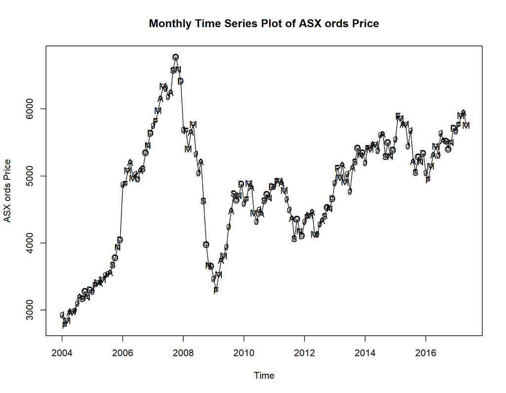

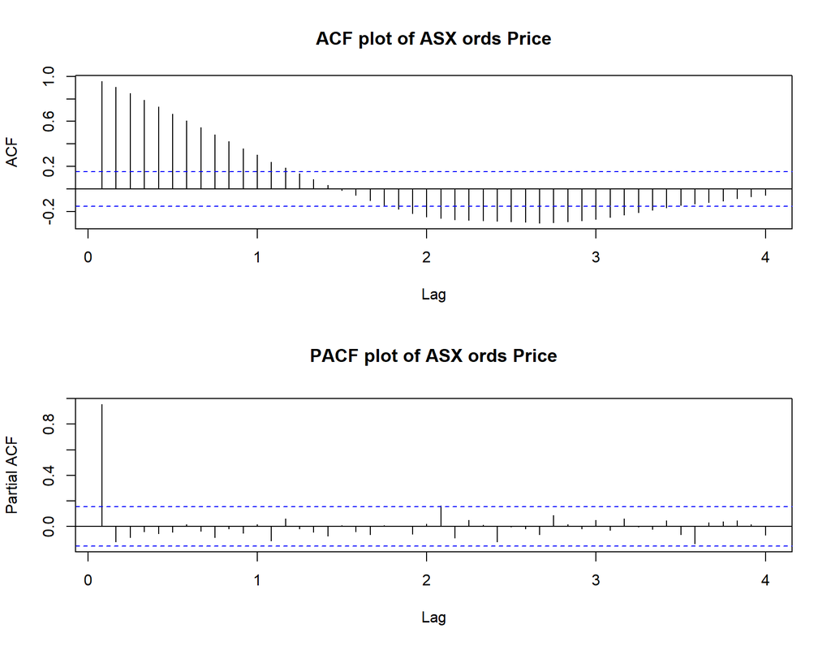

```
##
##  Augmented Dickey-Fuller Test
##
## data:  ts
## Dickey-Fuller = -2.6995, Lag order = 5, p-value = 0.2846
## alternative hypothesis: stationary
##
##
##  Phillips-Perron Unit Root Test
##
## data:  ts
## Dickey-Fuller Z(alpha) = -8.7417, Truncation lag parameter = 4, p-value
## = 0.6135
## alternative hypothesis: stationary
```

```r
descriptive_analysis(ASX_TS, "ASX ords Price")
```

There is upward trend in the ASX ords price index after 2009, as price dropped between 2008-09 and there is little bit of changing variance. Slowly decaying patterns from ACF plot confirm trend and highly significant co-relation lag on PACF plot stats non-stationarity.

P-value of ADF test and PP test is > 0.05, which gives statistically assurance that series is non-stationary.

**Gold Price**

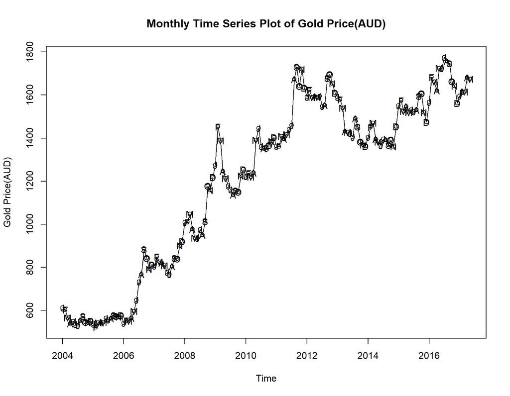

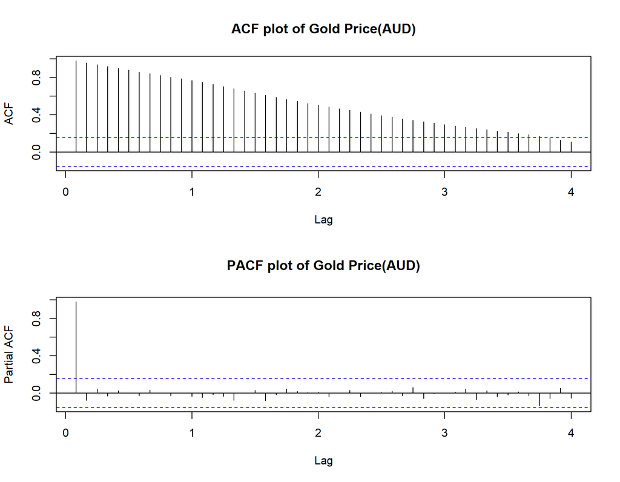

```
##
##  Augmented Dickey-Fuller Test
##
## data:  ts
## Dickey-Fuller = -1.8369, Lag order = 5, p-value = 0.6444
## alternative hypothesis: stationary
##
##
##  Phillips-Perron Unit Root Test
##
## data:  ts
## Dickey-Fuller Z(alpha) = -9.2725, Truncation lag parameter = 4, p-value
## = 0.5831
## alternative hypothesis: stationary
```

```r
descriptive_analysis(gold_TS, "Gold Price(AUD)")
```

There is obvious upward trend after 2006, while before that price was stable, there is no obvious changing variance and intervention point. Slowly decaying patterns from ACF plot confirm trend and highly significant co-relation lag on PACF plot stats non-stationarity. P-value of ADF test and PP test is > 0.05, which gives statistically assurance that series is non-stationary.

**Crude Oil Price**

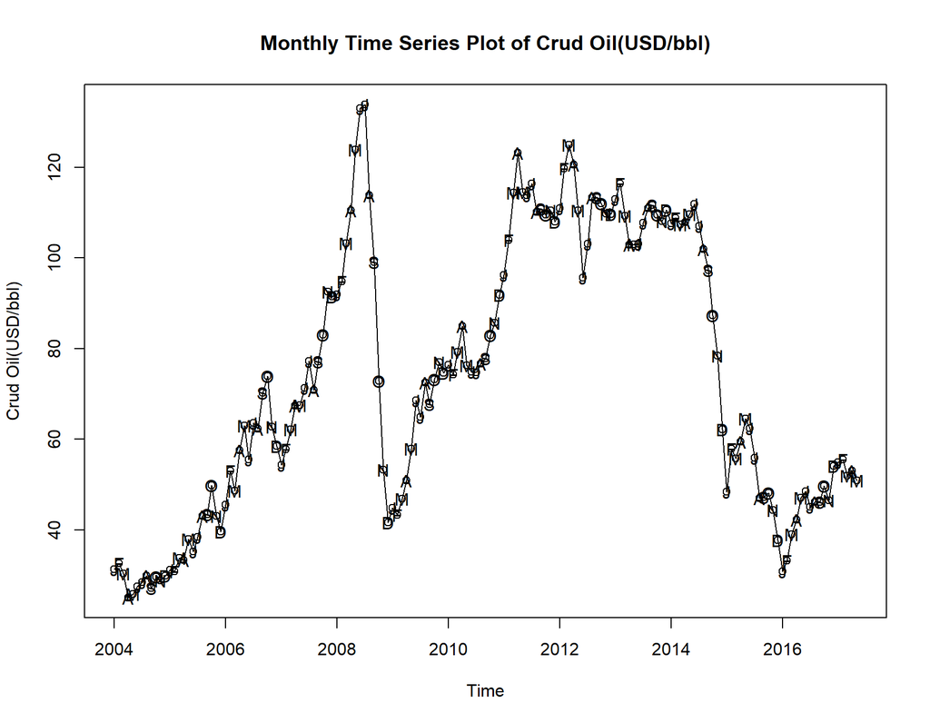

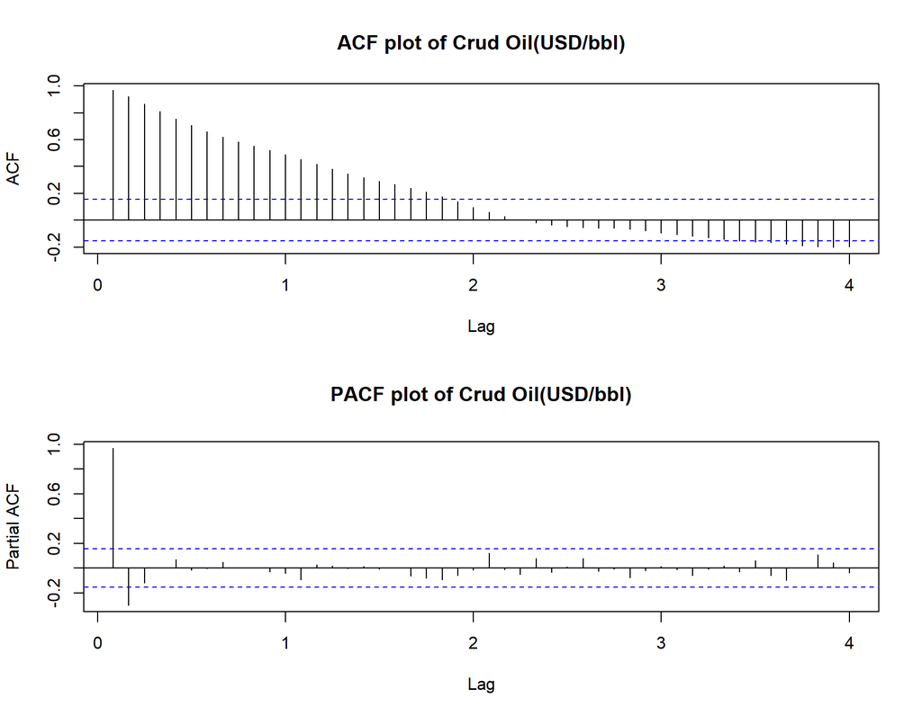

```
##
##  Augmented Dickey-Fuller Test
##
## data:  ts
## Dickey-Fuller = -1.8523, Lag order = 5, p-value = 0.6379
## alternative hypothesis: stationary
##
##
##  Phillips-Perron Unit Root Test
##
## data:  ts
## Dickey-Fuller Z(alpha) = -6.5927, Truncation lag parameter = 4, p-value
## = 0.7367
## alternative hypothesis: stationary
```

```r
descriptive_analysis(oil_TS, "Crud Oil(USD/bbl)")
```

There is intervention point at 2008 and little bit of changind variance and trend. Slowly decaying patterns from ACF plot confirm trend and highly significant co-relation lag on PACF plot stats non-stationarity. P-value of ADF test and PP test is > 0.05, which gives statistically assurance that series is non-stationary.

**Copper Price**

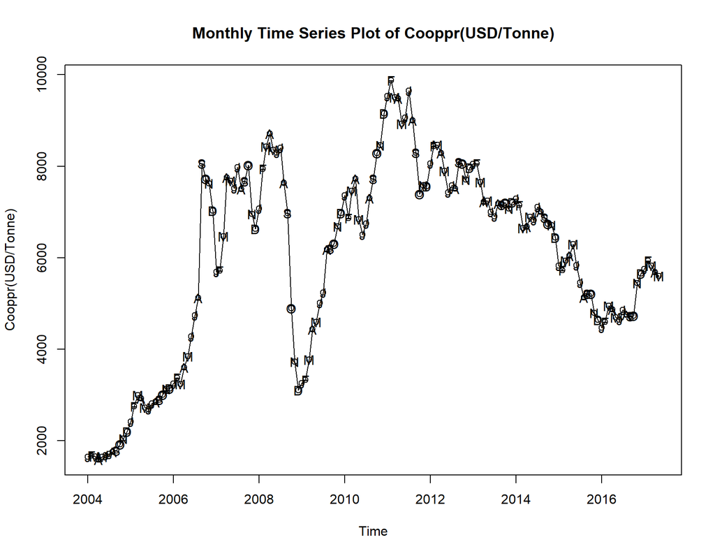

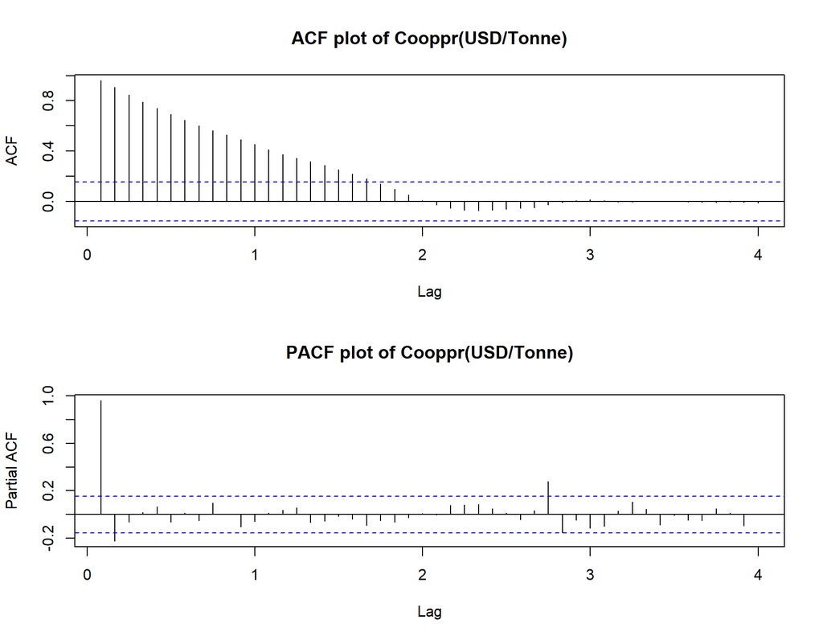

```
##
##  Augmented Dickey-Fuller Test
##
## data:  ts
## Dickey-Fuller = -2.2502, Lag order = 5, p-value = 0.472
## alternative hypothesis: stationary
##
##
##  Phillips-Perron Unit Root Test
##
## data:  ts
## Dickey-Fuller Z(alpha) = -7.8883, Truncation lag parameter = 4, p-value
## = 0.6624
## alternative hypothesis: stationary
```

```r
descriptive_analysis(copper_TS, "Cooppr(USD/Tonne)")
```

There is upward trend with intervention point in 2008, however after 2012, price dropped. There is changing variance.While PACF plot and unit root test gives statistically evidence that series is non-stationary.

Hence, the time-series is **Non-stationary**

## Box-Cox Transformation

To deal with changing variance and trend, transformation and differencing is required make the series stationary. However, order matters while performing these. Before doing differencing, we must do the transformation on time series.

After transforming, we have to check staionarity becasue sometimes, after transformation, series will become staionary without doing differencing.

**ASX Price**

```r
ASX_TS_lambda = BoxCox.lambda(ASX_TS)
ASX_TS_lambda
```

```
## [1] 1.999924
```

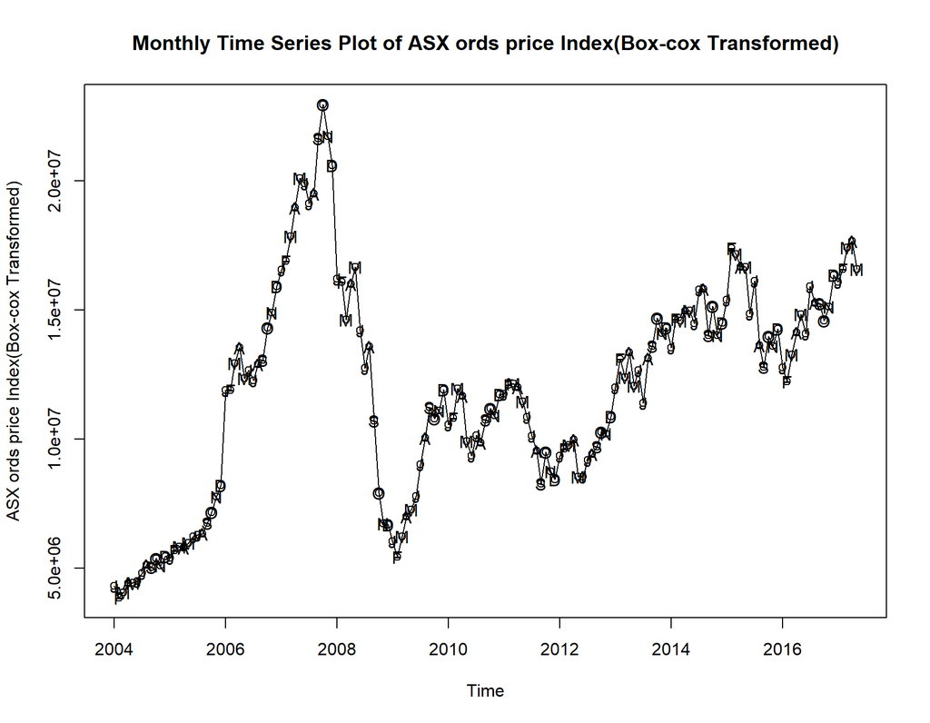

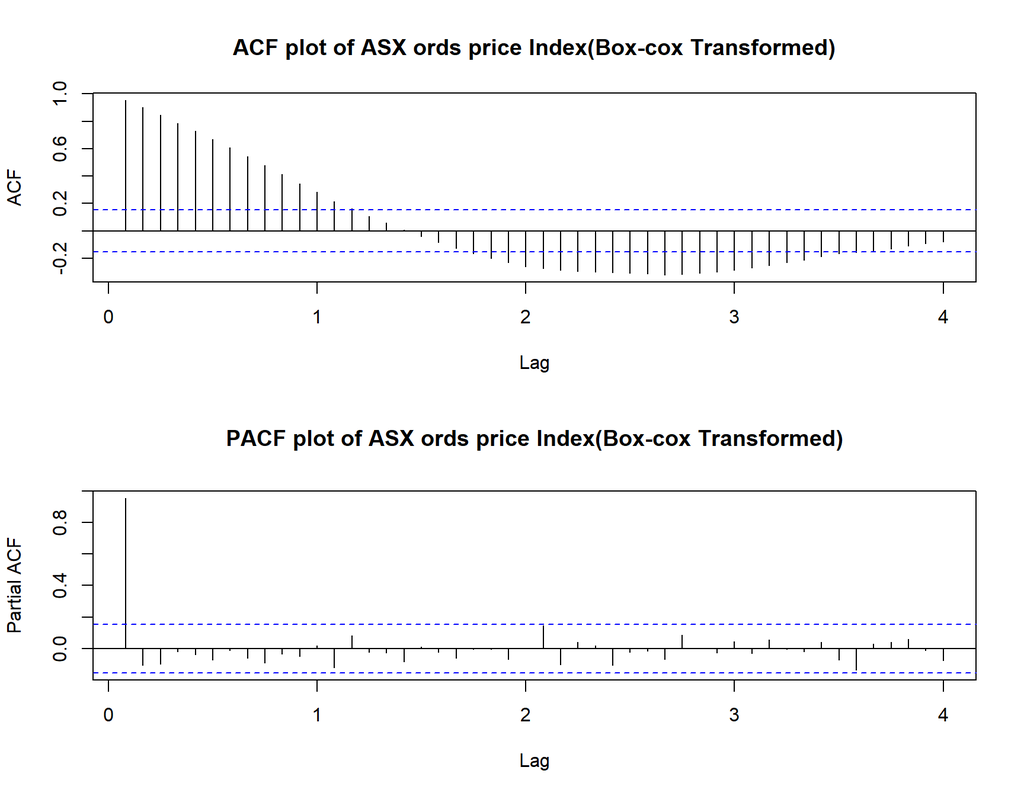

```
##
##  Augmented Dickey-Fuller Test
##
## data:  ts
## Dickey-Fuller = -2.5556, Lag order = 5, p-value = 0.3446
## alternative hypothesis: stationary
##
##
##  Phillips-Perron Unit Root Test
##
## data:  ts
## Dickey-Fuller Z(alpha) = -8.6601, Truncation lag parameter = 4, p-value
## = 0.6182
## alternative hypothesis: stationary
```

```r
ASX_TSBC = ((ASX_TS^(ASX_TS_lambda)) - 1) / ASX_TS_lambda
descriptive_analysis(ASX_TSBC,"ASX ords price Index(Box-cox Transformed)")
```

After doing box-cox transformation on the series with lambda = 1.99, series is still non-stationary which can be confirmed by visuals and unit root test. Hence, differencing is needed.

**Gold Price**

```r
gold_TS_lambda = BoxCox.lambda(gold_TS)
gold_TS_lambda
```

```
## [1] 0.976695
```

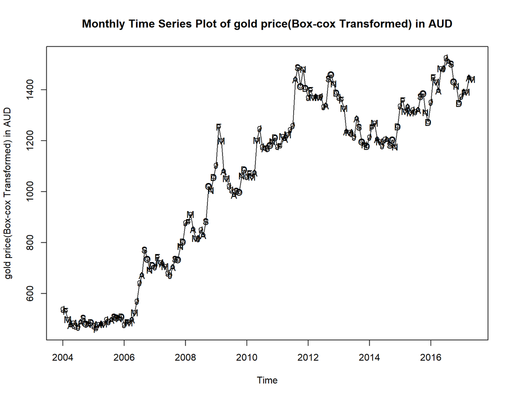

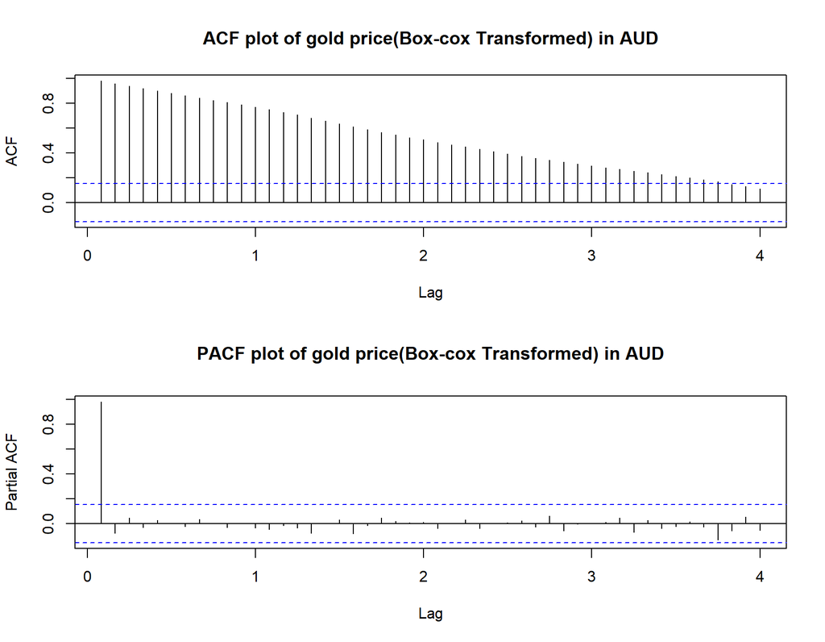

```
##
##  Augmented Dickey-Fuller Test
##
## data:  ts
## Dickey-Fuller = -1.8246, Lag order = 5, p-value = 0.6495
## alternative hypothesis: stationary
##
##
##  Phillips-Perron Unit Root Test
##
## data:  ts
## Dickey-Fuller Z(alpha) = -9.1607, Truncation lag parameter = 4, p-value
## = 0.5895
## alternative hypothesis: stationary
```

```r
gold_TSBC = ((gold_TS^(gold_TS_lambda)) - 1) / gold_TS_lambda
descriptive_analysis(gold_TSBC,"gold price(Box-cox Transformed) in AUD")
```

**Oil Price**

```r
oil_TS_lambda = BoxCox.lambda(oil_TS)
oil_TS_lambda
```

```
## [1] -0.8304136
```

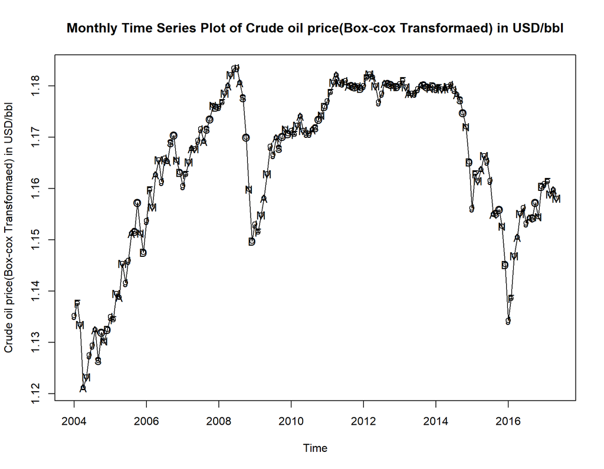

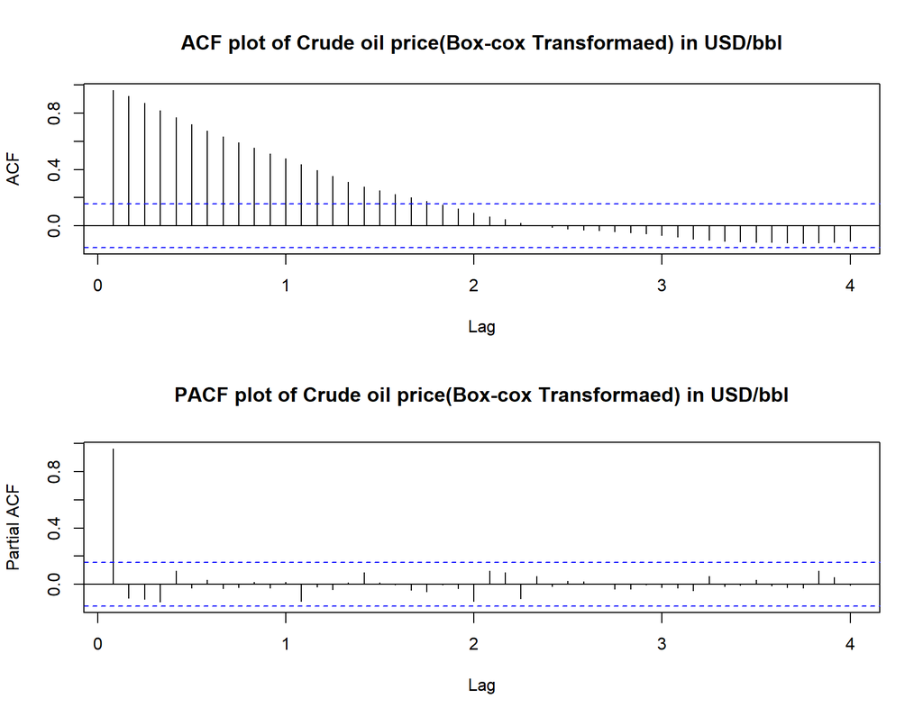

```
##
##  Augmented Dickey-Fuller Test
##
## data:  ts
## Dickey-Fuller = -2.1932, Lag order = 5, p-value = 0.4958
## alternative hypothesis: stationary
##
##
##  Phillips-Perron Unit Root Test
##
## data:  ts
## Dickey-Fuller Z(alpha) = -5.8301, Truncation lag parameter = 4, p-value
## = 0.7804
## alternative hypothesis: stationary
```

```r
oil_TSBC = ((oil_TS^(oil_TS_lambda)) - 1) / oil_TS_lambda
descriptive_analysis(oil_TSBC, "Crude oil price(Box-cox Transformaed) in USD/bbl")
```

**Copper**

```r
copper_TS_lambda = BoxCox.lambda(copper_TS)
copper_TS_lambda
```

```
## [1] 0.9336783
```

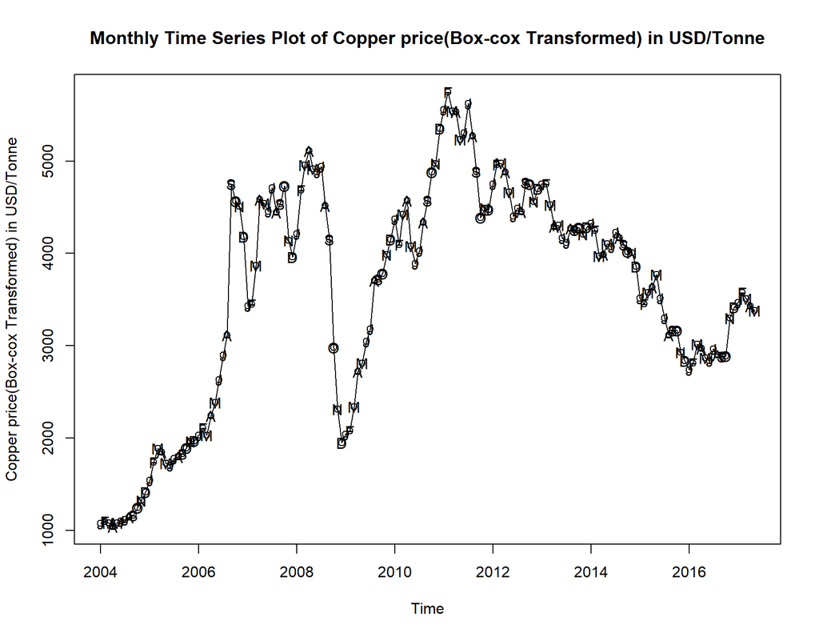

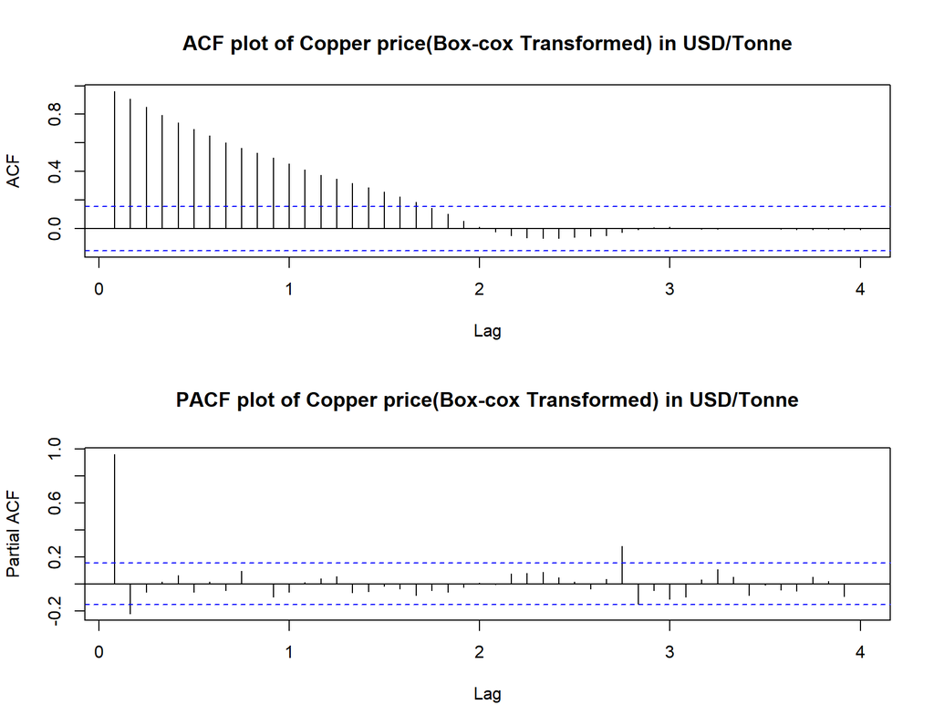

```
##
##  Augmented Dickey-Fuller Test
##
## data:  ts
## Dickey-Fuller = -2.2607, Lag order = 5, p-value = 0.4676
## alternative hypothesis: stationary
##
##
##  Phillips-Perron Unit Root Test
##
## data:  ts
## Dickey-Fuller Z(alpha) = -7.8192, Truncation lag parameter = 4, p-value
## = 0.6664
## alternative hypothesis: stationary
```

```r
copper_TSBC = ((copper_TS^(copper_TS_lambda)) - 1) / copper_TS_lambda
descriptive_analysis(copper_TSBC,"Copper price(Box-cox Transformed) in USD/Tonne")
```

Even though, changing variance is better in Box-cox Transformed series, non-stationarity is still exist in every time series object, which is statistically approved by visual plots and non-stationarity. Hence, **differencing** is needed to convert the series into stationary.

## Differencing

**ASX ord price index**

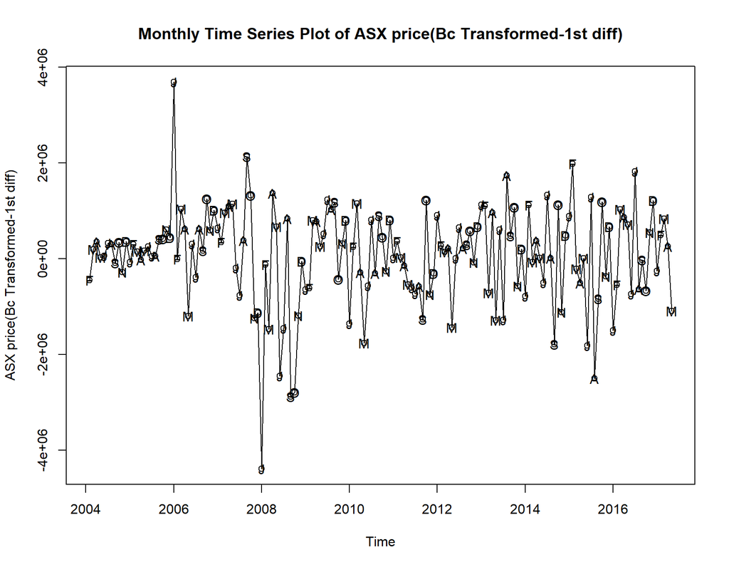

```
##
##  Augmented Dickey-Fuller Test
##
## data:  ts
## Dickey-Fuller = -4.4343, Lag order = 5, p-value = 0.01
## alternative hypothesis: stationary
```

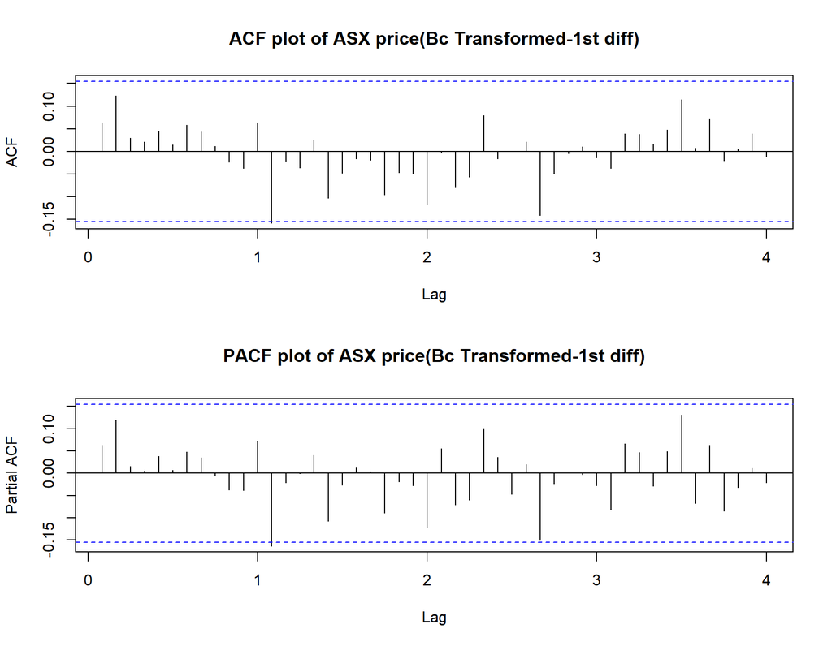

```
##
##  Phillips-Perron Unit Root Test
##
## data:  ts
## Dickey-Fuller Z(alpha) = -161.02, Truncation lag parameter = 4, p-value
## = 0.01
## alternative hypothesis: stationary
```

```r
ASX_TSBC_diff = diff(ASX_TSBC)
descriptive_analysis(ASX_TSBC_diff,"ASX price(Bc Transformed-1st diff)")
```

After takinf 1st order difference on box-cox transformed series, time series plot shows random pattern as series is mostly fluctuating around mean level with better changing variance.

There is no significant correlation lag in ACF and PACF plot.While p-value in both unit root test is < 0.01, indicating series is stationary.

Hence, Series is staionary now after doing boxcox transformatoin and 1sr order differencing.

**Gold Price**

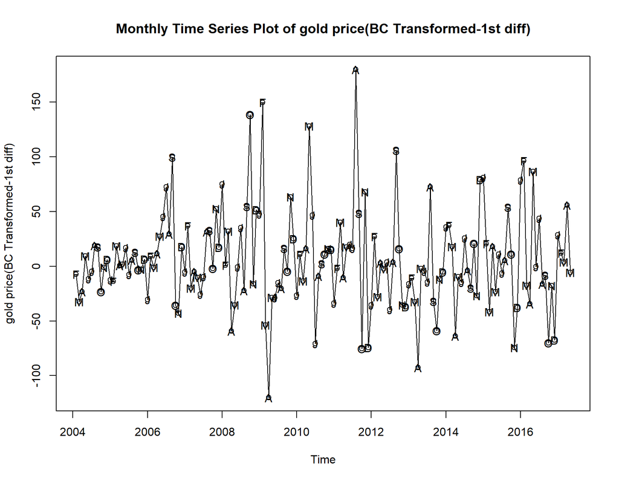

```
##
##  Augmented Dickey-Fuller Test
##
## data:  ts
## Dickey-Fuller = -5.876, Lag order = 5, p-value = 0.01
## alternative hypothesis: stationary
```

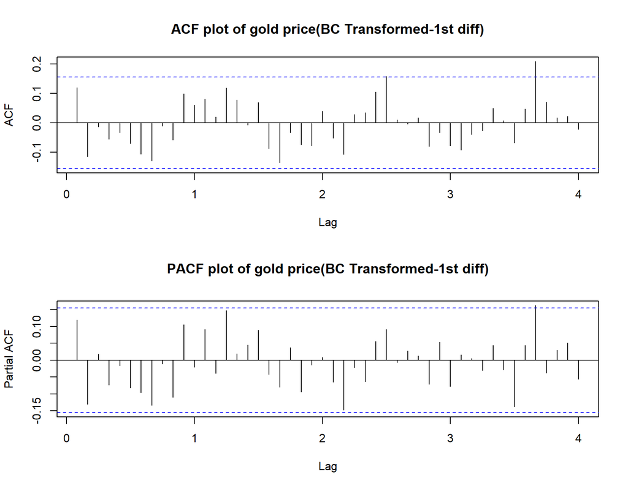

```
##
##  Phillips-Perron Unit Root Test
##
## data:  ts
## Dickey-Fuller Z(alpha) = -127.96, Truncation lag parameter = 4, p-value
## = 0.01
## alternative hypothesis: stationary
```

```r
gold_TSBC_diff = diff(gold_TSBC)
descriptive_analysis(gold_TSBC_diff,"gold price(BC Transformed-1st diff)")
```

**Oil Price**

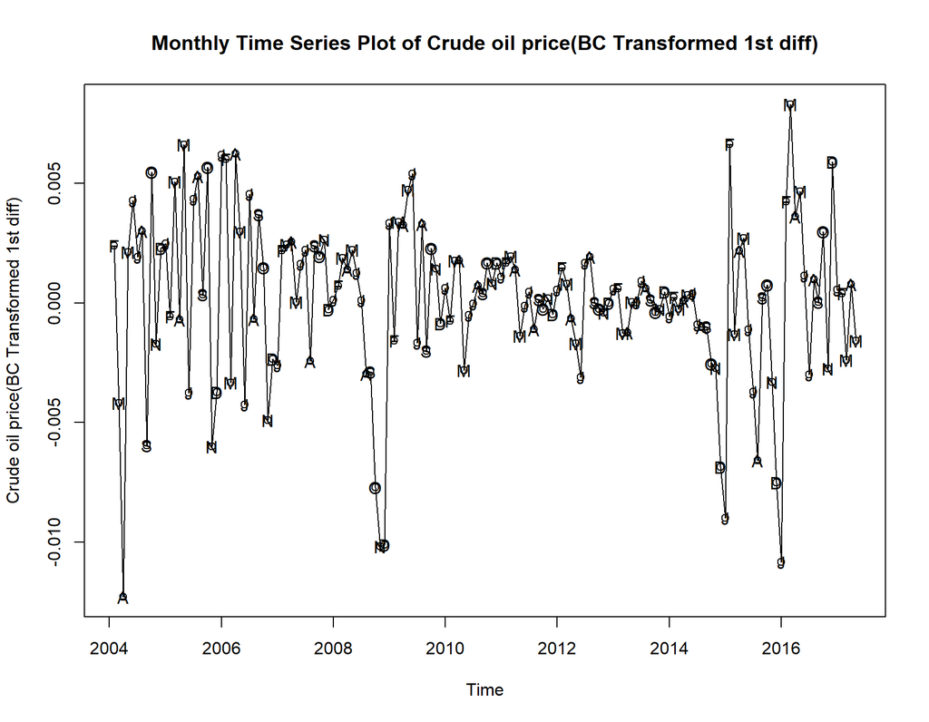

```
##
##  Augmented Dickey-Fuller Test
##
## data:  ts
## Dickey-Fuller = -5.5931, Lag order = 5, p-value = 0.01
## alternative hypothesis: stationary
```

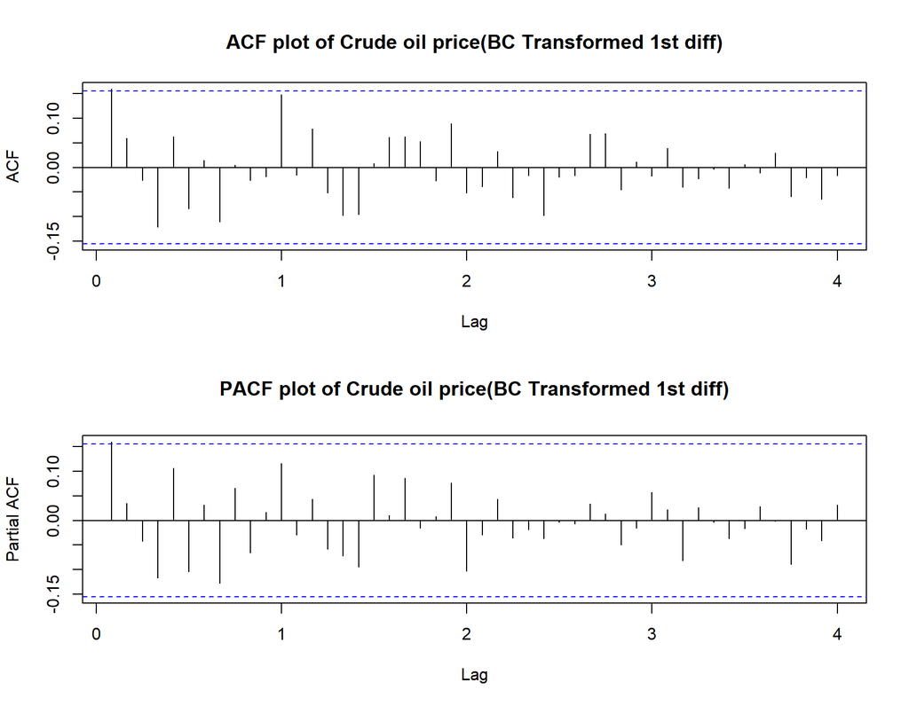

```
##
##  Phillips-Perron Unit Root Test
##
## data:  ts
## Dickey-Fuller Z(alpha) = -132.41, Truncation lag parameter = 4, p-value
## = 0.01
## alternative hypothesis: stationary
```

```r
oil_TSBC_diff = diff(oil_TSBC)
descriptive_analysis(oil_TSBC_diff, "Crude oil price(BC Transformed 1st diff)")
```

**Copper Price**

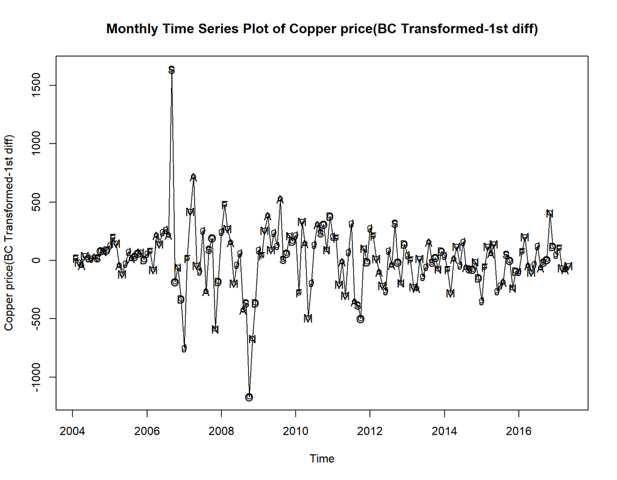

```
##
##  Augmented Dickey-Fuller Test
##
## data:  ts
## Dickey-Fuller = -5.4802, Lag order = 5, p-value = 0.01
## alternative hypothesis: stationary
```

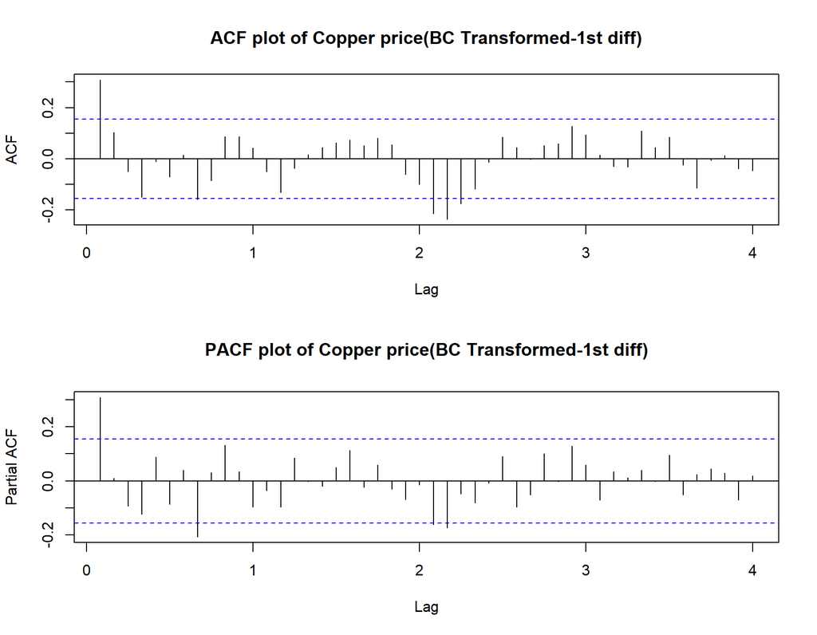

```
##
##  Phillips-Perron Unit Root Test
##
## data:  ts
## Dickey-Fuller Z(alpha) = -106.15, Truncation lag parameter = 4, p-value
## = 0.01
## alternative hypothesis: stationary
```

```r
copper_TSBC_diff = diff(copper_TSBC)
descriptive_analysis(copper_TSBC_diff,"Copper price(BC Transformed-1st diff)")
```

# **2.The impact of the components of a time series data**

We can analyse impact of trend and seasonality of time series decompose the series into trend, seasonlity and remainder. Decompositino can be done by x12 and stl functions.

## Decomposition

**ASX ords Price**

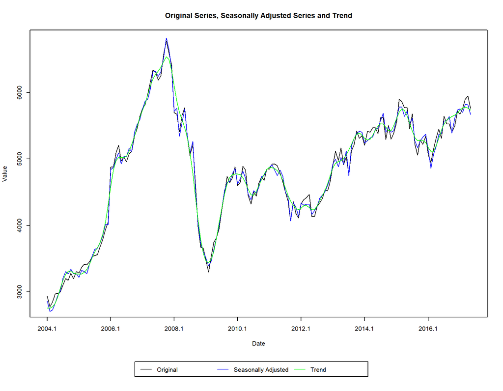

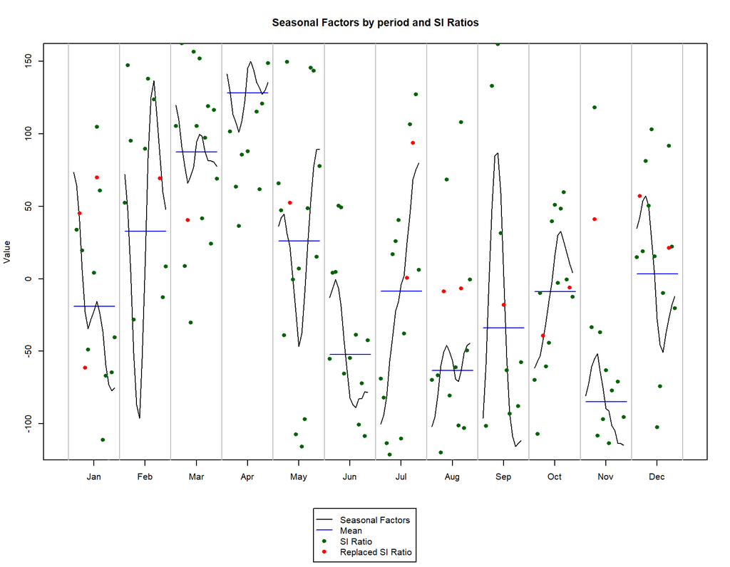

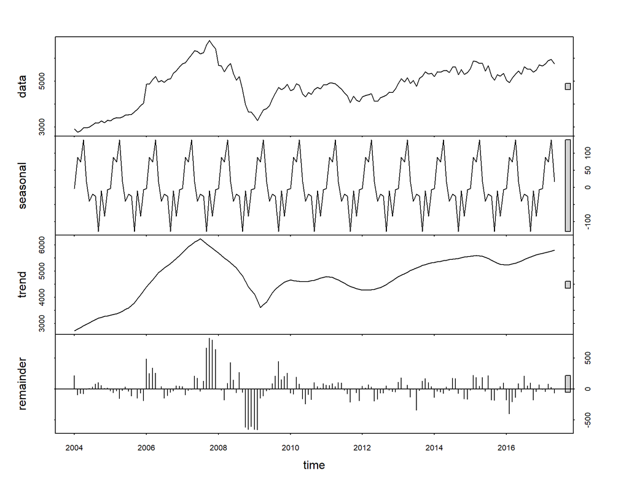

```r
decom(ASX_TS)
```

From x12 graph, it is depicts that seasonaly adjusted series is mostly overlapping the original series, while the trend is deviated slighly from original.

The adjusted seasonal factors are expected to have seaonal pattern around the mean level in every month, however factors are diverted and not following the seasonal pattern around mean for any month.

From STL graph, we can conclude that, trend follows the original pattern with positive trend, then getting dropped for few years and rising again. Few tall bars from remainder series are caused by some external factors. Since there is no indication of seasonality in the ACF and visualisation plot, seasonality in STL is not meaningful.

**Gold Price**

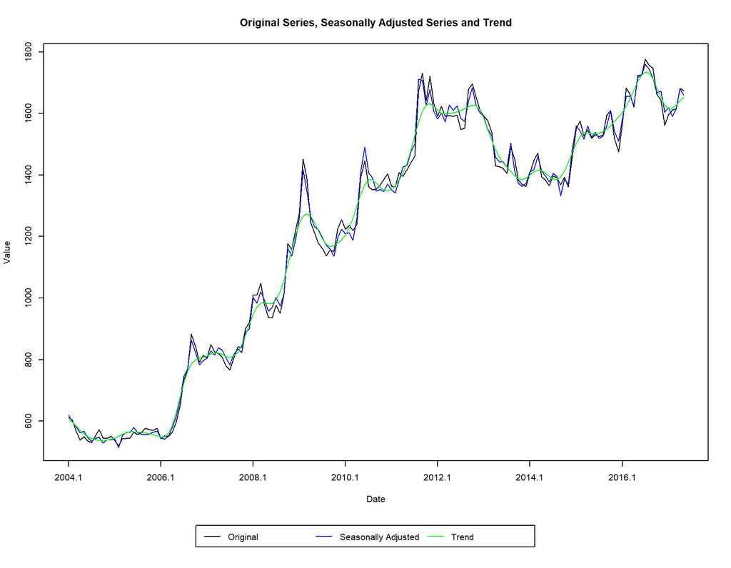

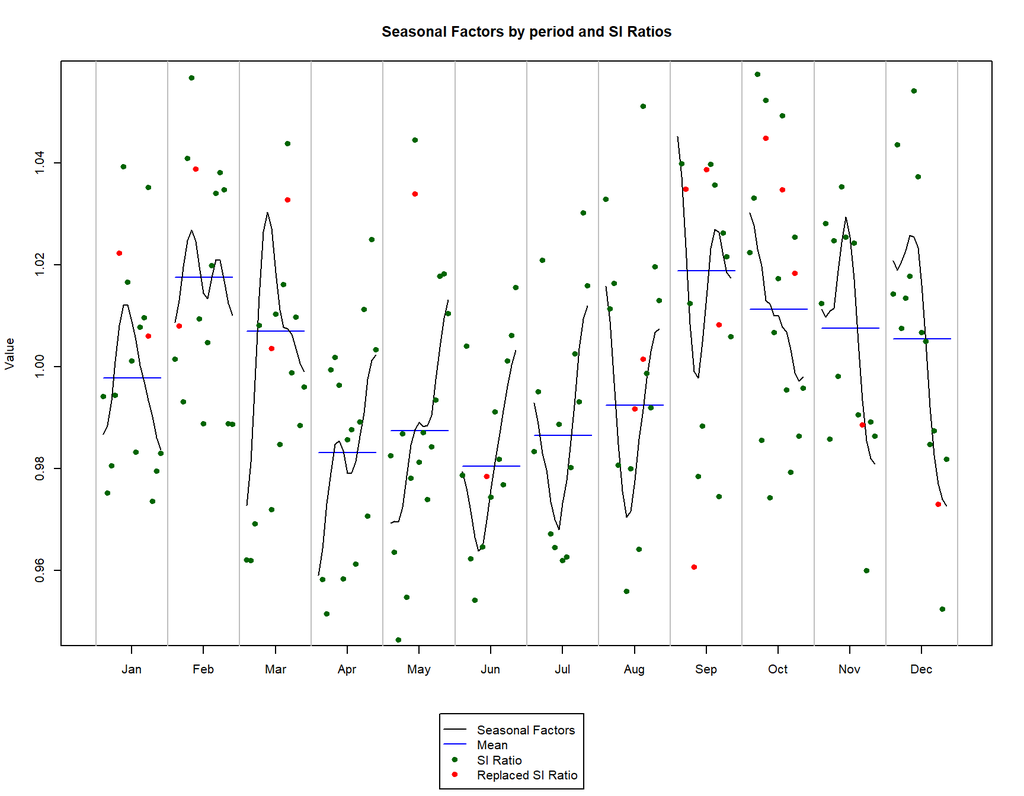

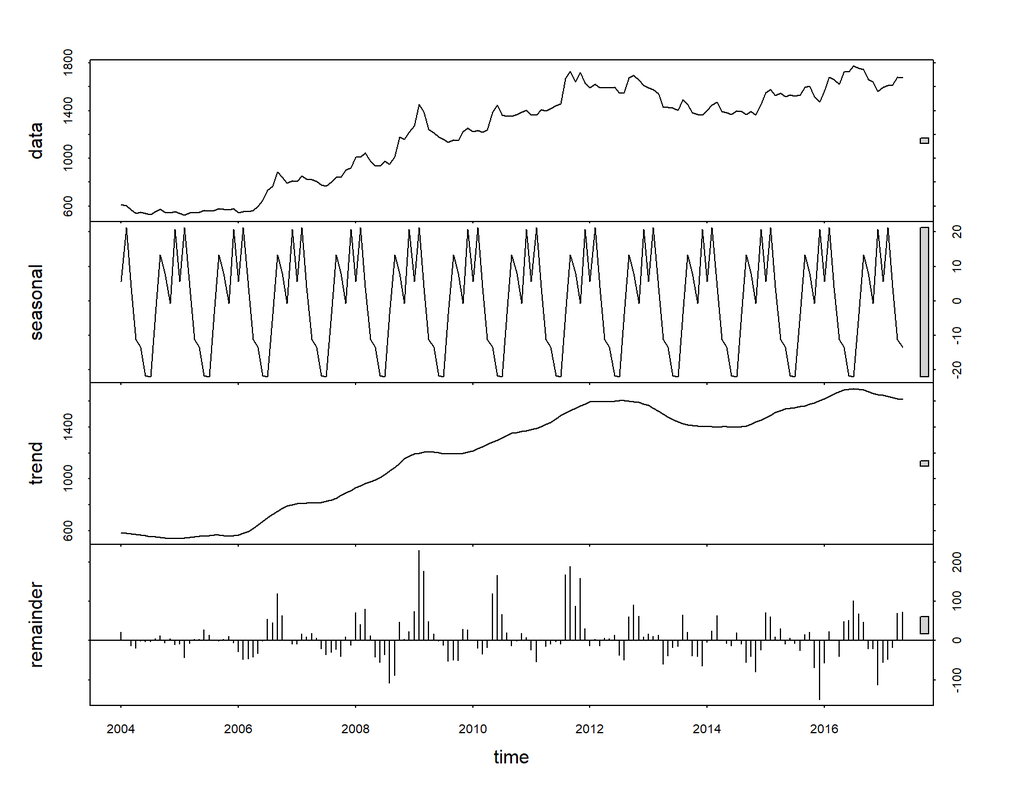

```r
decom(gold_TS)
```

From x12 graph, it is observed that seasonaly adjusted series is mostly overlapping the original series, while the trend is deviated slighly from original.

The adjusted seasonal factors are diverted and not following the seasonal pattern around mean for any month.